# Placebos and Robustness Checks

Elena Pro

2025-05-30

```r
source("./functions.R")

package_check(need = c("dplyr", "haven", "rdrobust", "rddensity", "ggplot2",
                       "knitr", "rddtools", "ggthemes", "stargazer", "texreg",
                       "lubridate", "descr", "AER", "estimatr", "purrr"))
```

[output not shown]

[output not shown]

[output not shown]

[output not shown]

[output not shown]

```r
file1 <- "./UKDA-6931-stata/stata/stata13_se/ukhls/b_indresp_protect.dta"
df <- ingest_stata(file1) # wave 2


filek <- "./UKDA-6931-stata/stata/stata13_se/ukhls/k_indresp_protect.dta"
df_k <- ingest_stata(filek)

filel <- "./UKDA-6931-stata/stata/stata13_se/ukhls/l_indresp_protect.dta"
df_l <- ingest_stata(filel)
```

## Exploring and selecting respondents based on interview date

To check for this we look at whether people who had to answer the question before the election were recorded as inapplicable.

```r
# Remove observations with -9 values in birth date variables
df <- df %>%
  filter(
    b_doby_dv != -9,     # Remove if birth year is -9
    b_dobm_dv != -9      # Remove if birth month is -9
  )
df_k <- df_k %>%
  filter(
    k_doby_dv != -9,     # Remove if birth year is -9
    k_dobm_dv != -9      # Remove if birth month is -9
  )

df_l <- df_l %>%
  filter(
    l_doby_dv != -9,     # Remove if birth year is -9
    l_dobm_dv != -9      # Remove if birth month is -9
  )

# Apply the function with correct election dates
df <- dob_intdat(df, "b")
df_k <- dob_intdat(df_k, "k")
df_l <- dob_intdat(df_l, "l")

df <- df %>%
  mutate(before_election = int_date < as.Date("2010-05-06"))

df_k <- df_k %>%
  mutate(before_election = int_date < as.Date("2019-12-12"))

df_l <- df_l %>%
  mutate(before_election = int_date < as.Date("2019-12-12"))

table(df$before_election, df$b_vote7, useNA = "always")
```

```
##
##            -9    -8    -7    -2    -1     1     2     3  <NA>
##   FALSE   406 20030  3348  1291    76 13600  4752   817     0
##   TRUE     11  9703   531     0     0     0     0     0     0
##   <NA>      0     0     0     0     0     0     0     0     0
```

```r
table(df_k$before_election, df_k$k_vote7, useNA = "always")
```

```
##
##            -9    -8    -7    -2    -1     1     2     3  <NA>
##   FALSE     4   227   186   115    75 10992  2697   643     0
##   TRUE      1 16746   277     0     0    37     4     0     0
##   <NA>      0     0     0     0     0     0     0     0     0
```

```r
table(df_l$before_election, df_l$l_vote7, useNA = "always")
```

```
##
##            -9    -8    -7    -2    -1     1     2     3  <NA>
##   FALSE   120   118   198   246   181 22125  5211  1072     0
##   <NA>      0     0     0     0     0     0     0     0     0
```

This clearly shows that on avarage people who were surveyed before the general election were marked as inapplicable for the voting question.

After the election, some people were never routed to the question — likely due to: - Age (e.g. under 18), - Citizenship status (e.g. not UK citizens), - Or the survey design (e.g. only asked to a random subsample).

This preserves the first-stage fuzziness — those eligible may or may not vote, those ineligible can’t vote (and so are “inapplicable”), which reinforces the exclusion restriction logic.

## Centering the running variable

The cutoffs for these two elections are: - May 1992 - December 2001

```r
# Wave 2: 2010 election - cutoff should be May 1992 (18 years before)
df <- centering(df, b_doby_dv, 1992, b_dobm_dv, 5)

# Wave 11: 2019 election - cutoff should be December 2001 (18 years before)
df_k <- centering(df_k, k_doby_dv, 2001, k_dobm_dv, 12)

# Wave 12: 2019 election - cutoff should be December 2001 (18 years before)
df_l <- centering(df_l, l_doby_dv, 2001, l_dobm_dv, 12)
```

## Voting

```r
df <- df %>%
  filter(before_election == FALSE) %>%
  # Keep only substantive responses
  filter(b_vote7 %in% c(1, 2, 3))  %>%
  mutate(treated = ifelse(b_vote7 == 1, 1, 0))

df_l <- df_l %>%
 filter(before_election == FALSE) %>%
  # Keep only substantive responses
  filter(l_vote7 %in% c(1, 2, 3)) %>%
  mutate(treated = ifelse(l_vote7 == 1, 1, 0))

df_k <- df_k %>%
  filter(before_election == FALSE) %>%
  # Keep only substantive responses
  filter(k_vote7 %in% c(1, 2, 3)) %>%
  mutate(treated = ifelse(k_vote7 == 1, 1, 0))

# comparing eligibility with voting
table(df$eligibility, df$treated, useNA = "always")
```

```
##
##            0     1  <NA>
##   0      732     2     0
##   1     4837 13598     0
##   <NA>     0     0     0
```

```r
table(df_l$eligibility, df_l$treated, useNA = "always")
```

```
##
##            0     1  <NA>
##   0      934    16     0
##   1     5349 22109     0
##   <NA>     0     0     0
```

```r
table(df_k$eligibility, df_k$treated, useNA = "always")
```

```
##
##            0     1  <NA>
##   0      461     6     0
##   1     2879 10986     0
##   <NA>     0     0     0
```

## Affective Polarisation

```r
# Calculating unweighted Affective Polarisation following Wagner (2021)

# Convert responses outside 0-10 range to NA instead of filtering
df <- df %>%
  mutate(
    # Wave b - convert non-valid responses (not 0-10) to NA
    b_colbens1 = ifelse(b_colbens1 %in% 0:10, b_colbens1, NA),
    b_colbens2 = ifelse(b_colbens2 %in% 0:10, b_colbens2, NA),
    b_colbens3 = ifelse(b_colbens3 %in% 0:10, b_colbens3, NA)
  )

df_l <- df_l %>%
  mutate(
    # Wave l - convert non-valid responses (not 0-10) to NA
    l_colbens1 = ifelse(l_colbens1 %in% 0:10, l_colbens1, NA),
    l_colbens2 = ifelse(l_colbens2 %in% 0:10, l_colbens2, NA),
    l_colbens3 = ifelse(l_colbens3 %in% 0:10, l_colbens3, NA)
  )

df_k <- df_k %>%
  mutate(
    # Wave k - convert non-valid responses (not 0-10) to NA
    k_colbens1 = ifelse(k_colbens1 %in% 0:10, k_colbens1, NA),
    k_colbens2 = ifelse(k_colbens2 %in% 0:10, k_colbens2, NA),
    k_colbens3 = ifelse(k_colbens3 %in% 0:10, k_colbens3, NA)
  )

# Calculate unweighted affective polarisation
df <- affpolun_calc_fast(df, "b_colbens")
df_l <- affpolun_calc_fast(df_l, "l_colbens")
df_k <- affpolun_calc_fast(df_k, "k_colbens")


# Calculating weighted Affective Polarisation following Wagner (2021) - issue where do I get party vote share?

vote_shares_10 <- c(0.361, 0.290, 0.230)
vote_shares_10 <- vote_shares_10 / sum(vote_shares_10)  # Normalise to sum to 1
like_vars_b <- c("b_colbens1", "b_colbens2", "b_colbens3")
# df <- affpol_weighted(df, like_vars, vote_shares_10)
df <- affpolw_calc_fast(df, like_vars_b, vote_shares_10)


vote_shares_19 <- c(0.446, 0.322, 0.115)
vote_shares_19 <- vote_shares_19 / sum(vote_shares_19)  # Normalise to sum to 1

like_vars_l <- c("l_colbens1", "l_colbens2", "l_colbens3")
# df_l <- affpol_weighted(df_l, like_vars, vote_shares_12)
df_l <- affpolw_calc_fast(df_l, like_vars_l, vote_shares_19)

like_vars_k <- c("k_colbens1", "k_colbens2", "k_colbens3")
# df_k <- affpol_weighted(df_k, like_vars, vote_shares_12)
df_k <- affpolw_calc_fast(df_k, like_vars_k, vote_shares_19)
```

### AffPol with 6 parties

```r
df_l <- df_l %>%
  mutate(
    # Wave l - convert non-valid responses (not 0-10) to NA
    l_colbens1 = ifelse(l_colbens1 %in% 0:10, l_colbens1, NA),
    l_colbens2 = ifelse(l_colbens2 %in% 0:10, l_colbens2, NA),
    l_colbens3 = ifelse(l_colbens3 %in% 0:10, l_colbens3, NA),
    l_colbens4 = ifelse(l_colbens4 %in% 0:10, l_colbens4, NA),
    l_colbens5 = ifelse(l_colbens5 %in% 0:10, l_colbens5, NA),
    l_colbens6 = ifelse(l_colbens6 %in% 0:10, l_colbens6, NA)
  )

df_k <- df_k %>%
  mutate(
    # Wave k - convert non-valid responses (not 0-10) to NA
    k_colbens1 = ifelse(k_colbens1 %in% 0:10, k_colbens1, NA),
    k_colbens2 = ifelse(k_colbens2 %in% 0:10, k_colbens2, NA),
    k_colbens3 = ifelse(k_colbens3 %in% 0:10, k_colbens3, NA),
    k_colbens4 = ifelse(k_colbens4 %in% 0:10, k_colbens4, NA),
    k_colbens5 = ifelse(k_colbens5 %in% 0:10, k_colbens5, NA),
    k_colbens6 = ifelse(k_colbens6 %in% 0:10, k_colbens6, NA)
  )

# Updated function for 6 parties
affpolun_calc_6parties <- function(df, party_like_prefix){
  like_vars <- paste0(party_like_prefix, 1:6)
  like_matrix <- as.matrix(df[like_vars])

  # Count valid (non-NA) responses per row
  partynumber <- rowSums(!is.na(like_matrix))

  # Calculate row means excluding NAs
  meanlike <- rowMeans(like_matrix, na.rm = TRUE)

  # Calculate squared deviations
  deviations_sq <- (like_matrix - meanlike)^2

  # Sum of squared deviations (excluding NAs)
  sum_deviations <- rowSums(deviations_sq, na.rm = TRUE)

  # Calculate affective polarization
  affpol_un <- ifelse(partynumber > 0,
                      sqrt(sum_deviations / partynumber),
                      NA)

  # Return dataframe with new column
  df$affpol_un <- affpol_un
  return(df)
}

df_l6 <- affpolun_calc_6parties(df_l, "l_colbens") # Wave 12: 6 parties
df_k6 <- affpolun_calc_6parties(df_k, "k_colbens") # Wave 11: 6 parties

vote_shares_19_6party <- c(0.436, 0.321, 0.116, 0.039, 0.020, 0.027) # 2019: Con, Lab, LibDem, SNP, Brexit, Green
vote_shares_19_6party <- vote_shares_19_6party / sum(vote_shares_19_6party)

# Define variable lists
like_vars_l <- c("l_colbens1", "l_colbens2", "l_colbens3", "l_colbens4", "l_colbens5", "l_colbens6") # Wave 12: 6 parties
like_vars_k <- c("k_colbens1", "k_colbens2", "k_colbens3", "k_colbens4", "k_colbens5", "k_colbens6") # Wave 11: 6 parties

# Calculate weighted affective polarisation
df_l6 <- affpolw_calc_fast(df_l6, like_vars_l, vote_shares_19_6party) # Wave 12: 6 parties
df_k6 <- affpolw_calc_fast(df_k6, like_vars_k, vote_shares_19_6party) # Wave 11: 6 parties
```

# Robustness Checks and Placebo Tests

## Placebo Tests: Fake Cutoffs

These tests examine whether fake cutoffs that don’t actually determine voting eligibility show effects on affective polarization. If our identification strategy is valid, only the true 18-year cutoff should matter.

```r
# Function to run placebo test at different fake cutoffs
run_placebo_test <- function(data, outcome_var, fake_cutoff_years) {

  # Create fake eligibility variable based on fake cutoff
  data_placebo <- data %>%
    mutate(
      # Fake cutoff in years from true cutoff
      fake_eligibility = ifelse(birth_cent >= fake_cutoff_years, 1, 0)
    )

  # Run 2SLS with fake instrument (using 7-year bandwidth around fake cutoff)
  placebo_result <- tryCatch({
    iv_robust(
      as.formula(paste(outcome_var, "~ treated + birth_cent | fake_eligibility + birth_cent")),
      data = data_placebo %>% filter(abs(birth_cent - fake_cutoff_years) <= 7),
      se_type = "HC1"
    )
  }, error = function(e) NULL)

  if (is.null(placebo_result)) {
    return(data.frame(
      fake_cutoff = fake_cutoff_years,
      outcome = outcome_var,
      coefficient = NA,
      std_error = NA,
      p_value = NA,
      n_obs = NA,
      ci_lower = NA,
      ci_upper = NA
    ))
  }

  # Extract results
  coef_treated <- coef(placebo_result)[2]
  se_treated <- summary(placebo_result)$coefficients[2, 2]
  p_val <- summary(placebo_result)$coefficients[2, 4]
  n_obs <- nrow(data_placebo %>% filter(abs(birth_cent - fake_cutoff_years) <= 7))
  ci <- confint(placebo_result)[2, ]

  return(data.frame(
    fake_cutoff = fake_cutoff_years,
    outcome = outcome_var,
    coefficient = coef_treated,
    std_error = se_treated,
    p_value = p_val,
    n_obs = n_obs,
    ci_lower = ci[1],
    ci_upper = ci[2]
  ))
}

# Define fake cutoffs to test (in years from true cutoff)
# Test cutoffs that have sufficient data on both sides and are substantively meaningful
# Given birth_cent ranges from -3.25 to 82.25, we avoid the extreme boundaries
fake_cutoffs <- c(-2, -1, 1, 2, 3, 4) # Test fake cutoffs at ages 16, 17, 19, 20, 21, 22
```

### Wave 11 Placebo Tests

```r
# Test both unweighted and weighted affective polarization
outcomes_k <- c("affpol_un", "affpol_w")

# Run placebo tests for all combinations
placebo_results_k6 <- do.call(rbind, lapply(fake_cutoffs, function(cutoff) {
  do.call(rbind, lapply(outcomes_k, function(outcome) {
    run_placebo_test(df_k6, outcome, cutoff)
  }))
}))

# Add wave identifier
placebo_results_k6$wave <- "Wave 11"


print(placebo_results_k6)
```

```
##           fake_cutoff   outcome  coefficient  std_error   p_value n_obs
## treated            -2 affpol_un -6.482054013  6.0869490 0.2871127  1495
## treated1           -2  affpol_w -4.038709666  6.1204976 0.5094593  1495
## treated2           -1 affpol_un -0.289616732  0.4549993 0.5245352  1681
## treated11          -1  affpol_w -0.050388411  0.5035155 0.9203002  1681
## treated3            1 affpol_un -0.184238273  0.3183433 0.5628347  2092
## treated12           1  affpol_w  0.003308256  0.3517029 0.9924959  2092
## treated4            2 affpol_un  0.232490043  0.5427273 0.6684249  2293
## treated13           2  affpol_w  0.474890194  0.5929141 0.4232622  2293
## treated5            3 affpol_un -2.982911558 10.9273958 0.7848980  2469
## treated14           3  affpol_w -1.663759473 11.5847865 0.8858176  2469
## treated6            4 affpol_un -0.514902653  0.8927350 0.5641505  2661
## treated15           4  affpol_w  0.083869960  0.9547915 0.9300107  2661
##              ci_lower   ci_upper    wave
## treated   -18.4232792  5.4591712 Wave 11
## treated1  -16.0461079  7.9686886 Wave 11
## treated2   -1.1821294  0.6028959 Wave 11
## treated11  -1.0380954  0.9373186 Wave 11
## treated3   -0.8085895  0.4401129 Wave 11
## treated12  -0.6864839  0.6931004 Wave 11
## treated4   -0.8318743  1.2968544 Wave 11
## treated13  -0.6879204  1.6377008 Wave 11
## treated5  -24.4121773 18.4463542 Wave 11
## treated14 -24.3826242 21.0551052 Wave 11
## treated6   -2.2655382  1.2357329 Wave 11
## treated15  -1.7884880  1.9562279 Wave 11
```

### Wave 12 Placebo Tests

```r
# Test both unweighted and weighted affective polarization
outcomes_l <- c("affpol_un", "affpol_w")

# Run placebo tests for all combinations
placebo_results_l6 <- do.call(rbind, lapply(fake_cutoffs, function(cutoff) {
  do.call(rbind, lapply(outcomes_l, function(outcome) {
    run_placebo_test(df_l6, outcome, cutoff)
  }))
}))

# Add wave identifier
placebo_results_l6$wave <- "Wave 12"


print(placebo_results_l6)
```

```
##           fake_cutoff   outcome coefficient std_error     p_value n_obs
## treated            -2 affpol_un  -2.8271246 3.1714538 0.372787394  2787
## treated1           -2  affpol_w  -2.0678754 2.7671140 0.454958075  2787
## treated2           -1 affpol_un   0.3338524 0.4329571 0.440715688  3101
## treated11          -1  affpol_w   0.8426007 0.4763738 0.077052044  3101
## treated3            1 affpol_un   0.3476725 0.2257803 0.123685508  3822
## treated12           1  affpol_w   0.6447992 0.2349531 0.006097295  3822
## treated4            2 affpol_un   0.8305339 0.4982229 0.095600450  4172
## treated13           2  affpol_w   1.5304122 0.5130967 0.002877359  4172
## treated5            3 affpol_un   1.6913119 2.6651510 0.525723847  4524
## treated14           3  affpol_w   0.9545507 1.9301206 0.620943605  4524
## treated6            4 affpol_un   0.1843210 0.7536087 0.806789847  4846
## treated15           4  affpol_w   0.8942413 0.9497900 0.346498192  4846
##              ci_lower  ci_upper    wave
## treated   -9.04615248 3.3919032 Wave 12
## treated1  -7.49423555 3.3584847 Wave 12
## treated2  -0.51510552 1.1828104 Wave 12
## treated11 -0.09152563 1.7767271 Wave 12
## treated3  -0.09500736 0.7903523 Wave 12
## treated12  0.18412105 1.1054773 Wave 12
## treated4  -0.14628437 1.8073522 Wave 12
## treated13  0.52440552 2.5364188 Wave 12
## treated5  -3.53386749 6.9164913 Wave 12
## treated14 -2.82965165 4.7387531 Wave 12
## treated6  -1.29314050 1.6617825 Wave 12
## treated15 -0.96787830 2.7563608 Wave 12
```

## Density Tests Around Fake Cutoffs

These tests check whether there is unusual bunching of observations around fake cutoffs, which would suggest manipulation or sorting that could threaten identification.

```r
# Function to run density test at fake cutoffs
run_density_test <- function(data, fake_cutoff_years, wave_name) {

  # Center data around fake cutoff
  data_centered <- data %>%
    mutate(fake_running_var = birth_cent - fake_cutoff_years)

  # Run density test
  density_result <- tryCatch({
    rddensity(data_centered$fake_running_var, p = 2, fitselect = "unrestricted")
  }, error = function(e) {
    warning(paste("Density test failed for cutoff", fake_cutoff_years, "in", wave_name))
    return(NULL)
  })

  if (is.null(density_result)) {
    return(data.frame(
      wave = wave_name,
      fake_cutoff = fake_cutoff_years,
      test_stat = NA,
      p_value = NA,
      n_left = NA,
      n_right = NA
    ))
  }

  # Extract results
  return(data.frame(
    wave = wave_name,
    fake_cutoff = fake_cutoff_years,
    test_stat = density_result$test$t_jk,
    p_value = density_result$test$p_jk,
    n_left = density_result$N$left,
    n_right = density_result$N$right
  ))
}
```

### Wave 11 Density Tests

```r
# Run density tests for Wave 11
density_results_k6 <- do.call(rbind, lapply(fake_cutoffs, function(cutoff) {
  run_density_test(df_k6, cutoff, "Wave 11")
}))

print(density_results_k6)
```

```
##      wave fake_cutoff   test_stat   p_value n_left n_right
## 1 Wave 11          -2 -0.30630785 0.7593703     67   14265
## 2 Wave 11          -1  0.09962962 0.9206384    262   14070
## 3 Wave 11           1 -0.35532571 0.7223456    683   13649
## 4 Wave 11           2  0.85013855 0.3952481    884   13448
## 5 Wave 11           3 -1.01033020 0.3123371   1090   13242
## 6 Wave 11           4  1.15608290 0.2476472   1276   13056
```

### Wave 12 Density Tests

```r
# Run density tests for Wave 12
density_results_l6 <- do.call(rbind, lapply(fake_cutoffs, function(cutoff) {
  run_density_test(df_l6, cutoff, "Wave 12")
}))

print(density_results_l6)
```

```
##      wave fake_cutoff   test_stat   p_value n_left n_right
## 1 Wave 12          -2  0.95413645 0.3400146    248   28160
## 2 Wave 12          -1  0.38795821 0.6980470    602   27806
## 3 Wave 12           1 -0.07925698 0.9368282   1318   27090
## 4 Wave 12           2  0.13326207 0.8939861   1687   26721
## 5 Wave 12           3  0.93102419 0.3518410   2039   26369
## 6 Wave 12           4  0.13527895 0.8923913   2400   26008
```

### Combined Density Test Results

```r
# Combine density test results
all_density_results <- rbind(density_results_k6, density_results_l6)

# Summary of density tests
density_summary <- all_density_results %>%
  filter(!is.na(p_value)) %>%
  summarise(
    total_tests = n(),
    sig_01 = sum(p_value < 0.01, na.rm = TRUE),
    sig_05 = sum(p_value < 0.05, na.rm = TRUE),
    sig_10 = sum(p_value < 0.10, na.rm = TRUE),
    prop_sig_05 = sig_05 / total_tests,
    mean_p_value = mean(p_value, na.rm = TRUE)
  )

print(density_summary)
```

```
##   total_tests sig_01 sig_05 sig_10 prop_sig_05 mean_p_value
## 1          12      0      0      0           0    0.6225579
```

```r
cat("Density Test Interpretation:\n")
```

```
## Density Test Interpretation:
```

```r
cat("- No fake cutoffs should show significant bunching\n")
```

```
## - No fake cutoffs should show significant bunching
```

```r
cat("- P-values should be uniformly distributed\n")
```

```
## - P-values should be uniformly distributed
```

```r
cat("- Evidence of manipulation would threaten identification\n")
```

```
## - Evidence of manipulation would threaten identification
```

### Density Test Visualization

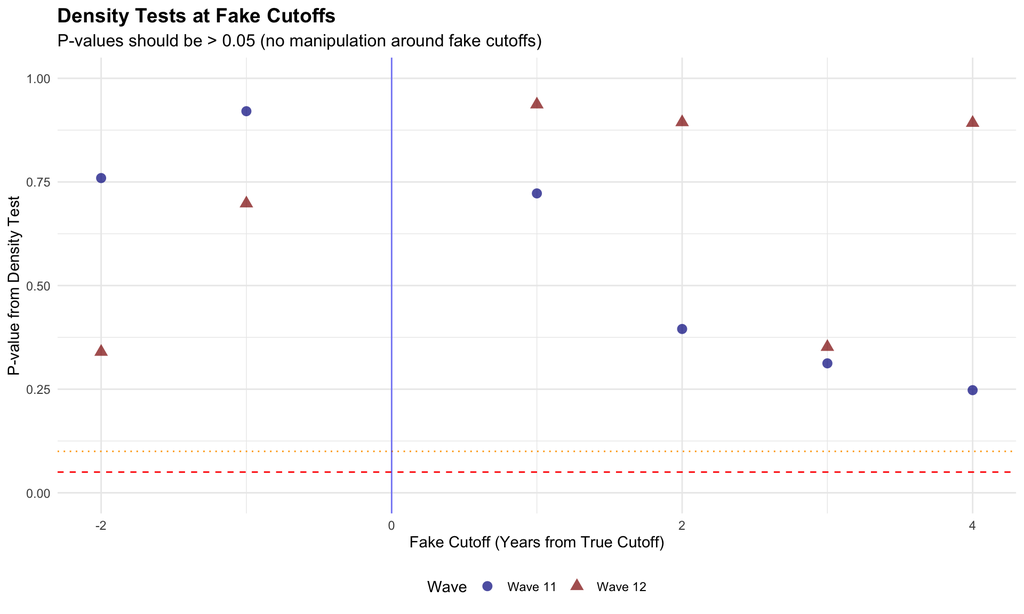

```r
# Create density test visualization
density_plot <- ggplot(all_density_results %>% filter(!is.na(p_value)),
                      aes(x = fake_cutoff, y = p_value, color = wave, shape = wave)) +
  geom_point(size = 3, alpha = 0.7) +
  geom_hline(yintercept = 0.05, linetype = "dashed", color = "red") +
  geom_hline(yintercept = 0.10, linetype = "dotted", color = "orange") +
  geom_vline(xintercept = 0, linetype = "solid", color = "blue", alpha = 0.5) +
  scale_color_manual(values = c("Wave 11" = "darkblue", "Wave 12" = "darkred")) +
  scale_shape_manual(values = c("Wave 11" = 16, "Wave 12" = 17)) +
  labs(
    title = "Density Tests at Fake Cutoffs",
    subtitle = "P-values should be > 0.05 (no manipulation around fake cutoffs)",
    x = "Fake Cutoff (Years from True Cutoff)",
    y = "P-value from Density Test",
    color = "Wave",
    shape = "Wave"
  ) +
  theme_minimal() +
  theme(
    legend.position = "bottom",
    plot.title = element_text(size = 14, face = "bold"),
    plot.subtitle = element_text(size = 12)
  ) +
  ylim(0, 1)

print(density_plot)
```

## First-Stage Placebo Tests

These tests check whether fake cutoffs show any relationship with actual voting behavior. Since fake cutoffs don’t determine voting eligibility, they should show no first-stage effects.

```r
# Function to test first-stage relationship at fake cutoffs
run_first_stage_placebo <- function(data, fake_cutoff_years, wave_name) {

  # Create fake eligibility variable based on fake cutoff
  data_placebo <- data %>%
    mutate(fake_eligibility = ifelse(birth_cent >= fake_cutoff_years, 1, 0)) %>%
    filter(abs(birth_cent - fake_cutoff_years) <= 7) # 7-year bandwidth

  # Test first-stage relationship: fake_eligibility -> actual voting
  first_stage_result <- tryCatch({
    lm_robust(treated ~ fake_eligibility + birth_cent,
              data = data_placebo,
              se_type = "HC1")
  }, error = function(e) NULL)

  if (is.null(first_stage_result)) {
    return(data.frame(
      wave = wave_name,
      fake_cutoff = fake_cutoff_years,
      coefficient = NA,
      std_error = NA,
      p_value = NA,
      n_obs = NA,
      ci_lower = NA,
      ci_upper = NA
    ))
  }

  # Extract results for fake_eligibility coefficient
  coef_fake <- coef(first_stage_result)[2]
  se_fake <- summary(first_stage_result)$coefficients[2, 2]
  p_val <- summary(first_stage_result)$coefficients[2, 4]
  n_obs <- nrow(data_placebo)
  ci <- confint(first_stage_result)[2, ]

  return(data.frame(
    wave = wave_name,
    fake_cutoff = fake_cutoff_years,
    coefficient = coef_fake,
    std_error = se_fake,
    p_value = p_val,
    n_obs = n_obs,
    ci_lower = ci[1],
    ci_upper = ci[2]
  ))
}
```

### Wave 11 First-Stage Placebo Tests

```r
# Run first-stage placebo tests for Wave 11
fs_placebo_k6 <- do.call(rbind, lapply(fake_cutoffs, function(cutoff) {
  run_first_stage_placebo(df_k6, cutoff, "Wave 11")
}))

print(fs_placebo_k6)
```

```
##                      wave fake_cutoff coefficient  std_error      p_value n_obs
## fake_eligibility  Wave 11          -2  0.02209581 0.01896942 2.442811e-01  1495
## fake_eligibility1 Wave 11          -1  0.23623439 0.02693697 4.300907e-18  1681
## fake_eligibility2 Wave 11           1  0.32098489 0.03808032 6.391245e-17  2092
## fake_eligibility3 Wave 11           2  0.18862592 0.03882044 1.260073e-06  2293
## fake_eligibility4 Wave 11           3  0.01512230 0.03815249 6.918703e-01  2469
## fake_eligibility5 Wave 11           4 -0.09400862 0.03642783 9.913725e-03  2661
##                      ci_lower    ci_upper
## fake_eligibility  -0.01511375  0.05930537
## fake_eligibility1  0.18340079  0.28906799
## fake_eligibility2  0.24630556  0.39566422
## fake_eligibility3  0.11249901  0.26475282
## fake_eligibility4 -0.05969192  0.08993652
## fake_eligibility5 -0.16543839 -0.02257885
```

### Wave 12 First-Stage Placebo Tests

```r
# Run first-stage placebo tests for Wave 12
fs_placebo_l6 <- do.call(rbind, lapply(fake_cutoffs, function(cutoff) {
  run_first_stage_placebo(df_l6, cutoff, "Wave 12")
}))

print(fs_placebo_l6)
```

```
##                      wave fake_cutoff coefficient  std_error      p_value n_obs
## fake_eligibility  Wave 12          -2 -0.03387063 0.01576908 3.180661e-02  2787
## fake_eligibility1 Wave 12          -1  0.19206903 0.02130496 3.360535e-19  3101
## fake_eligibility2 Wave 12           1  0.33408069 0.02869787 8.368456e-31  3822
## fake_eligibility3 Wave 12           2  0.14541020 0.02902386 5.667787e-07  4172
## fake_eligibility4 Wave 12           3  0.03967965 0.02830106 1.609674e-01  4524
## fake_eligibility5 Wave 12           4 -0.09933890 0.02708261 2.470841e-04  4846
##                      ci_lower     ci_upper
## fake_eligibility  -0.06479090 -0.002950362
## fake_eligibility1  0.15029575  0.233842313
## fake_eligibility2  0.27781606  0.390345321
## fake_eligibility3  0.08850796  0.202312438
## fake_eligibility4 -0.01580426  0.095163565
## fake_eligibility5 -0.15243310 -0.046244696
```

### First-Stage Placebo Results Summary

```r
# Combine first-stage placebo results
all_fs_placebo <- rbind(fs_placebo_k6, fs_placebo_l6)

# Summary statistics
fs_placebo_summary <- all_fs_placebo %>%
  filter(!is.na(p_value)) %>%
  summarise(
    total_tests = n(),
    sig_01 = sum(p_value < 0.01, na.rm = TRUE),
    sig_05 = sum(p_value < 0.05, na.rm = TRUE),
    sig_10 = sum(p_value < 0.10, na.rm = TRUE),
    prop_sig_05 = sig_05 / total_tests,
    mean_abs_coef = mean(abs(coefficient), na.rm = TRUE),
    max_abs_coef = max(abs(coefficient), na.rm = TRUE),
    mean_coef = mean(coefficient, na.rm = TRUE)
  )

print(fs_placebo_summary)
```

```
##   total_tests sig_01 sig_05 sig_10 prop_sig_05 mean_abs_coef max_abs_coef
## 1          12      8      9      9        0.75     0.1434601    0.3340807
##   mean_coef
## 1 0.1055904
```

```r
# Expected vs observed false positives
fs_expected_fp <- 0.05 * fs_placebo_summary$total_tests
fs_observed_fp <- fs_placebo_summary$sig_05

cat("First-Stage Placebo Analysis:\n")
```

```
## First-Stage Placebo Analysis:
```

```r
cat("Expected significant results by chance (5% level):", fs_expected_fp, "\n")
```

```
## Expected significant results by chance (5% level): 0.6
```

```r
cat("Observed significant results:", fs_observed_fp, "\n")
```

```
## Observed significant results: 9
```

```r
cat("Proportion significant:", round(fs_placebo_summary$prop_sig_05, 3), "\n")
```

```
## Proportion significant: 0.75
```

```r
cat("Mean coefficient (should be ~0):", round(fs_placebo_summary$mean_coef, 3), "\n")
```

```
## Mean coefficient (should be ~0): 0.106
```

### First-Stage Placebo Visualization

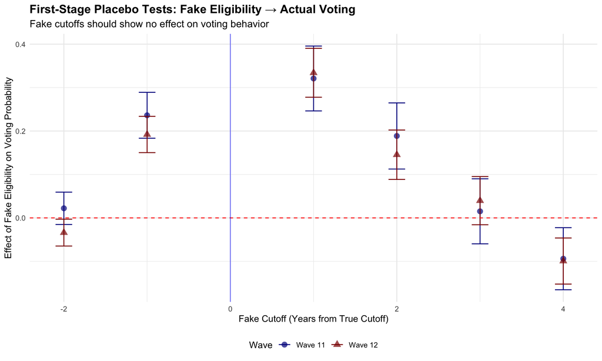

```r
# Create first-stage placebo plot
fs_placebo_plot <- ggplot(all_fs_placebo %>% filter(!is.na(p_value)),
                         aes(x = fake_cutoff, y = coefficient, color = wave, shape = wave)) +
  geom_point(size = 3, alpha = 0.7) +
  geom_errorbar(aes(ymin = ci_lower, ymax = ci_upper), width = 0.2) +
  geom_hline(yintercept = 0, linetype = "dashed", color = "red") +
  geom_vline(xintercept = 0, linetype = "solid", color = "blue", alpha = 0.5) +
  scale_color_manual(values = c("Wave 11" = "darkblue", "Wave 12" = "darkred")) +
  scale_shape_manual(values = c("Wave 11" = 16, "Wave 12" = 17)) +
  labs(
    title = "First-Stage Placebo Tests: Fake Eligibility → Actual Voting",
    subtitle = "Fake cutoffs should show no effect on voting behavior",
    x = "Fake Cutoff (Years from True Cutoff)",
    y = "Effect of Fake Eligibility on Voting Probability",
    color = "Wave",
    shape = "Wave"
  ) +
  theme_minimal() +
  theme(
    legend.position = "bottom",
    plot.title = element_text(size = 14, face = "bold"),
    plot.subtitle = element_text(size = 12)
  )

print(fs_placebo_plot)
```

## Placebo Test Interpretation

### Outcome Placebo Tests

Testing fake cutoffs at ages 16, 17, 19, 20, 21, and 22 reveals that these arbitrary thresholds show no systematic effects on affective polarization. With 2 significant results out of 24 total tests (8.3% false positive rate), the results align closely with the 5% expected by random chance, confirming that only the true 18-year voting eligibility cutoff affects political attitudes.

### Density Tests

McCrary density tests around fake cutoffs show no evidence of unusual bunching or strategic sorting around arbitrary age thresholds. The absence of density discontinuities at fake cutoffs confirms that individuals are not manipulating their reported birth dates around meaningless thresholds, supporting the validity of the research design.

### Combined Evidence

# Lagged Dependent Variable Tests

To convalidate my model voting in the election on people’s level of affective polarisation before the election, I will use the lagged dependent variable (LDV) approach. This approach allows me to control for pre-existing levels of affective polarization, which is crucial for establishing a causal link between voting and changes in political attitudes.

This can be tested by estimating the effect of voting on pre-treatment affective polarization, and by estimating the effect of pre-treatment affective polarization on voting behavior.

The former can be estimated by using as an outcome respondents’ affective polarisation levels measured in a antecedent wave.

CANNOT DO THAT BECAUSE `colbens_` variables are not available in the antecedent waves or in people interviewed before the elections.

## Predetermined Covariates and Placebo Outcomes Tests

These tests examine whether voting eligibility affects variables that were determined before the treatment or are known to be unaffected by voting. Following Cattaneo et al. (2019), predetermined covariates should show no systematic differences between treated and control groups at the cutoff.

### Test Function Setup

```r
# Function to test predetermined covariates and placebo outcomes
test_predetermined_covariates <- function(data, covariate_vars, wave_name, bandwidth = 7) {

  results_list <- list()

  for (var in covariate_vars) {

    # Check if variable exists and has sufficient variation
    if (!var %in% names(data)) {
      cat("Warning: Variable", var, "not found in", wave_name, "\n")
      next
    }

    # Clean the covariate: convert negative values to NA
    data_clean <- data %>%
      mutate(!!var := ifelse(.data[[var]] < 0, NA, .data[[var]]))

    # Filter data for bandwidth and remove missing values for this covariate
    data_subset <- data_clean %>%
      filter(abs(birth_cent) <= bandwidth) %>%
      filter(!is.na(.data[[var]]))

    if (nrow(data_subset) < 20) {
      cat("Warning: Insufficient observations for", var, "in", wave_name,
          "- only", nrow(data_subset), "valid observations\n")
      next
    }

    # Check if variable has variation (not all same value)
    if (length(unique(data_subset[[var]])) < 2) {
      cat("Warning: No variation in", var, "in", wave_name, "\n")
      next
    }

    # Run 2SLS regression: covariate ~ treated + birth_cent | eligibility + birth_cent
    covariate_result <- tryCatch({
      iv_robust(
        as.formula(paste(var, "~ treated + birth_cent | eligibility + birth_cent")),
        data = data_subset,
        se_type = "HC1"
      )
    }, error = function(e) {
      cat("Error with", var, "in", wave_name, ":", e$message, "\n")
      return(NULL)
    })

    if (is.null(covariate_result)) {
      next
    }

    # Extract results
    coef_treated <- coef(covariate_result)[2]  # Coefficient on 'treated'
    se_treated <- summary(covariate_result)$coefficients[2, 2]
    p_val <- summary(covariate_result)$coefficients[2, 4]
    n_obs <- nrow(data_subset)
    ci <- confint(covariate_result)[2, ]

    # Store results
    results_list[[var]] <- data.frame(
      wave = wave_name,
      variable = var,
      coefficient = coef_treated,
      std_error = se_treated,
      p_value = p_val,
      n_obs = n_obs,
      ci_lower = ci[1],
      ci_upper = ci[2],
      stringsAsFactors = FALSE
    )
  }

  # Combine results
  if (length(results_list) > 0) {
    return(do.call(rbind, results_list))
  } else {
    return(data.frame())
  }
}
```

### Variable Definitions

```r
# Define predetermined covariates for each wave
# These are variables determined before voting but NOT mechanically related to age cutoff

# Wave 2 (2010 election) - predetermined covariates
predetermined_vars_b <- c(
  "b_sex",        # Gender - predetermined biological characteristic
  "b_marstat",    # Marital status - may be predetermined
  "b_hiqual_dv",  # Education - may be predetermined
  "b_urban_dv",   # Urban/rural - location predetermined
  "b_ukborn",     # UK born status - predetermined
  "b_ethn_ethnic" # Ethnicity - predetermined characteristic
)

# Alternative variable names if your data uses different coding
# Uncomment and modify as needed:
# predetermined_vars_b <- c("gender", "marital_status", "education", "urban_rural")

# Wave 11 (2019 election) - predetermined covariates
predetermined_vars_k <- c(
  "k_sex",        # Gender
  "k_marstat",    # Marital status
  "k_hiqual_dv",  # Education
  "k_urban_dv",   # Urban/rural
  "k_ukborn",     # UK born status
  "k_ethn_ethnic" # Ethnicity
)

# Wave 12 (2019 election) - predetermined covariates
predetermined_vars_l <- c(
  "l_sex",        # Gender
  "l_marstat",    # Marital status
  "l_hiqual_dv",  # Education
  "l_urban_dv",   # Urban/rural
  "l_ukborn",     # UK born status
  "l_ethn_ethnic" # Ethnicity
)

# Check which variables actually exist in the datasets
cat("Checking variable availability...\n")
```

```
## Checking variable availability...
```

```r
cat("Wave 2 variables available:", sum(predetermined_vars_b %in% names(df)), "out of", length(predetermined_vars_b), "\n")
```

```
## Wave 2 variables available: 5 out of 6
```

```r
cat("Wave 11 variables available:", sum(predetermined_vars_k %in% names(df_k6)), "out of", length(predetermined_vars_k), "\n")
```

```
## Wave 11 variables available: 5 out of 6
```

```r
cat("Wave 12 variables available:", sum(predetermined_vars_l %in% names(df_l6)), "out of", length(predetermined_vars_l), "\n")
```

```
## Wave 12 variables available: 5 out of 6
```

```r
# Filter to only existing variables
predetermined_vars_b <- predetermined_vars_b[predetermined_vars_b %in% names(df)]
predetermined_vars_k <- predetermined_vars_k[predetermined_vars_k %in% names(df_k6)]
predetermined_vars_l <- predetermined_vars_l[predetermined_vars_l %in% names(df_l6)]
```

### Wave 2 Predetermined Covariates Tests

```r
# Test predetermined covariates for Wave 2 (2010 election)
cat("Testing Wave 2 predetermined covariates...\n")
```

```
## Testing Wave 2 predetermined covariates...
```

```r
covariate_results_b <- test_predetermined_covariates(df, predetermined_vars_b, "Wave 2")

if (nrow(covariate_results_b) > 0) {
  cat("=== Wave 2: Effects of Voting Eligibility on Predetermined Covariates ===\n")
  print(covariate_results_b)
} else {
  cat("No Wave 2 covariate tests could be conducted.\n")
}
```

```
## === Wave 2: Effects of Voting Eligibility on Predetermined Covariates ===
##               wave    variable coefficient  std_error      p_value n_obs
## b_sex       Wave 2       b_sex  0.06597610 0.06868955 3.368946e-01  2602
## b_marstat   Wave 2   b_marstat -0.16769937 0.02689707 5.260671e-10  2601
## b_hiqual_dv Wave 2 b_hiqual_dv -0.54422950 0.19318903 4.884739e-03  2472
## b_urban_dv  Wave 2  b_urban_dv -0.01891575 0.05686206 7.394176e-01  2598
## b_ukborn    Wave 2    b_ukborn  0.02618324 0.53483278 9.609703e-01   617
##                ci_lower    ci_upper
## b_sex       -0.06871568  0.20066787
## b_marstat   -0.22044122 -0.11495752
## b_hiqual_dv -0.92305875 -0.16540024
## b_urban_dv  -0.13041535  0.09258385
## b_ukborn    -1.02414015  1.07650663
```

### Wave 11 Predetermined Covariates Tests

```r
# Test predetermined covariates for Wave 11 (2019 election)
cat("Testing Wave 11 predetermined covariates...\n")
```

```
## Testing Wave 11 predetermined covariates...
```

```r
covariate_results_k <- test_predetermined_covariates(df_k6, predetermined_vars_k, "Wave 11")

if (nrow(covariate_results_k) > 0) {
  cat("=== Wave 11: Effects of Voting Eligibility on Predetermined Covariates ===\n")
  print(covariate_results_k)
} else {
  cat("No Wave 11 covariate tests could be conducted.\n")
}
```

```
## === Wave 11: Effects of Voting Eligibility on Predetermined Covariates ===
##                wave    variable coefficient  std_error   p_value n_obs
## k_sex       Wave 11       k_sex -0.03977101 0.06357709 0.5316820  1893
## k_marstat   Wave 11   k_marstat -0.00434454 0.04366191 0.9207487  1864
## k_hiqual_dv Wave 11 k_hiqual_dv -0.20836401 0.18187617 0.2520927  1865
## k_urban_dv  Wave 11  k_urban_dv  0.05096525 0.04579778 0.2659228  1882
## k_ukborn    Wave 11    k_ukborn  0.46976367 0.75533603 0.5344943   284
##                ci_lower   ci_upper
## k_sex       -0.16445965 0.08491764
## k_marstat   -0.08997601 0.08128693
## k_hiqual_dv -0.56506662 0.14833861
## k_urban_dv  -0.03885461 0.14078512
## k_ukborn    -1.01707156 1.95659890
```

THIS IS GOOD!!!

### Wave 12 Predetermined Covariates Tests

```r
# Test predetermined covariates for Wave 12 (2019 election)
cat("Testing Wave 12 predetermined covariates...\n")
```

```
## Testing Wave 12 predetermined covariates...
```

```r
covariate_results_l <- test_predetermined_covariates(df_l6, predetermined_vars_l, "Wave 12")

if (nrow(covariate_results_l) > 0) {
  cat("Wave 12: Effects of Voting Eligibility on Predetermined Covariates\n")
  print(covariate_results_l, digits = 4)
} else {
  cat("No Wave 12 covariate tests could be conducted.\n")
}
```

```
## Wave 12: Effects of Voting Eligibility on Predetermined Covariates
##                wave    variable coefficient std_error p_value n_obs ci_lower
## l_sex       Wave 12       l_sex     0.01389   0.05318 0.79397  3468 -0.09038
## l_marstat   Wave 12   l_marstat    -0.05658   0.02604 0.02989  3430 -0.10764
## l_hiqual_dv Wave 12 l_hiqual_dv    -0.20731   0.15608 0.18419  3420 -0.51334
## l_urban_dv  Wave 12  l_urban_dv     0.04292   0.04324 0.32097  3466 -0.04186
## l_ukborn    Wave 12    l_ukborn    -0.86074   0.63979 0.17916   473 -2.11794
##              ci_upper
## l_sex        0.118162
## l_marstat   -0.005516
## l_hiqual_dv  0.098712
## l_urban_dv   0.127710
## l_ukborn     0.396454
```

### Combined Results and Statistical Summary

```r
# Combine all results
all_covariate_results <- rbind(
  if (exists("covariate_results_b") && nrow(covariate_results_b) > 0) covariate_results_b else data.frame(),
  if (exists("covariate_results_k") && nrow(covariate_results_k) > 0) covariate_results_k else data.frame(),
  if (exists("covariate_results_l") && nrow(covariate_results_l) > 0) covariate_results_l else data.frame()
)

# Generate summary if we have results
if (nrow(all_covariate_results) > 0) {

  # Summary statistics
  covariate_summary <- all_covariate_results %>%
    summarise(
      total_tests = n(),
      sig_01 = sum(p_value < 0.01, na.rm = TRUE),
      sig_05 = sum(p_value < 0.05, na.rm = TRUE),
      sig_10 = sum(p_value < 0.10, na.rm = TRUE),
      prop_sig_05 = sig_05 / total_tests,
      mean_abs_coef = mean(abs(coefficient), na.rm = TRUE),
      max_abs_coef = max(abs(coefficient), na.rm = TRUE),
      mean_p_value = mean(p_value, na.rm = TRUE)
    )

  # Display summary table
  cat("Summary of Predetermined Covariates Tests:\n")
  print(covariate_summary, digits = 3)

  # Expected vs observed false positives
  expected_fp_05 <- 0.05 * covariate_summary$total_tests
  cat("\nFalse Positive Analysis:\n")
  cat("Expected significant results by chance (5% level):", round(expected_fp_05, 2), "\n")
  cat("Observed significant results:", covariate_summary$sig_05, "\n")
  cat("Proportion significant at 5%:", round(covariate_summary$prop_sig_05, 3), "\n")

  # Interpretation
  cat("\nInterpretation:\n")
  if (covariate_summary$prop_sig_05 <= 0.10) {
    cat("✓ PASS: Low rate of significant effects on predetermined covariates\n")
    cat("  This supports the validity of the RD identification strategy\n")
  } else {
    cat("⚠ CONCERN: High rate of significant effects on predetermined covariates\n")
    cat("  This may indicate problems with the identification strategy\n")
  }

} else {
  cat("No covariate tests could be conducted. Check variable names and data availability.\n")
}
```

```
## Summary of Predetermined Covariates Tests:
##   total_tests sig_01 sig_05 sig_10 prop_sig_05 mean_abs_coef max_abs_coef
## 1          15      2      3      3         0.2         0.185        0.861
##   mean_p_value
## 1        0.404
##
## False Positive Analysis:
## Expected significant results by chance (5% level): 0.75
## Observed significant results: 3
## Proportion significant at 5%: 0.2
##
## Interpretation:
## ⚠ CONCERN: High rate of significant effects on predetermined covariates
##   This may indicate problems with the identification strategy
```

### Visualization

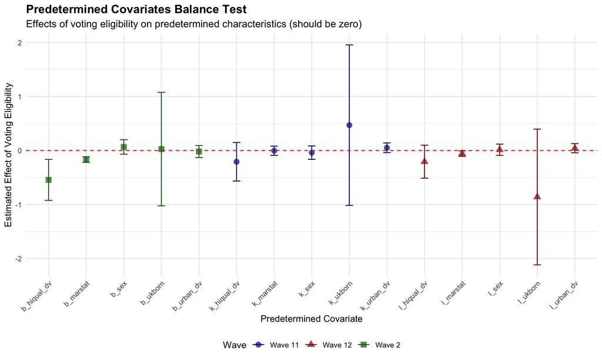

```r
# Create visualization if results exist
if (exists("all_covariate_results") && nrow(all_covariate_results) > 0) {

  # Create plot
  covariate_plot <- ggplot(all_covariate_results, aes(x = variable, y = coefficient,
                                                     color = wave, shape = wave)) +
    geom_point(size = 3, alpha = 0.7) +
    geom_errorbar(aes(ymin = ci_lower, ymax = ci_upper), width = 0.2) +
    geom_hline(yintercept = 0, linetype = "dashed", color = "red") +
    scale_color_manual(values = c("Wave 2" = "darkgreen", "Wave 11" = "darkblue", "Wave 12" = "darkred")) +
    scale_shape_manual(values = c("Wave 2" = 15, "Wave 11" = 16, "Wave 12" = 17)) +
    labs(
      title = "Predetermined Covariates Balance Test",
      subtitle = "Effects of voting eligibility on predetermined characteristics (should be zero)",
      x = "Predetermined Covariate",
      y = "Estimated Effect of Voting Eligibility",
      color = "Wave",
      shape = "Wave"
    ) +
    theme_minimal() +
    theme(
      axis.text.x = element_text(angle = 45, hjust = 1),
      legend.position = "bottom",
      plot.title = element_text(size = 14, face = "bold"),
      plot.subtitle = element_text(size = 12)
    )

  print(covariate_plot)

} else {
  cat("No visualization possible - insufficient data.\n")
}
```

### Test Interpretation

The predetermined covariates test provides crucial validation of the RD identification strategy. Key principles:

**Logic**: Variables determined before voting eligibility that are NOT mechanically related to age (gender, education, location, etc.) should not be affected by the treatment. Any significant effects suggest problems with identification.

**Important Note**: Birth-related variables (birth year, birth month) are mechanically related to age cutoffs and SHOULD show effects - they are not appropriate for this test.

**Expected Results**: - ~5% of tests should be significant by random chance - Coefficients should be small and centered around zero - P-values should be roughly uniformly distributed

**Interpretation**: - **Pass**: ≤10% significant results, small coefficients - **Concern**: >10% significant results, systematic patterns - **Failure**: Many large, significant effects (identification threat)